# Aion Online Topic Modelling

## About

When talking about MMORPG (massive multiplayer online role playing game) communities, a hot point of contention between the western and eastern markets is often the form of monetization. While Chinese and Korean markets generally prefer free to play titles with the addition of microtransactions, which often factor directly into gameplay, western markets often do not appreciate the ability to obtain an advantage using real life currency, and instead prefer games with an upfront cost (buy to play) or subscription (pay to play), which does not offer said advantages.

This clash of ideologies came to a head on the 23rd of June, when the 2009 hit MMORPG Aion was re-released as a classic version in the west. Rather than replicating its original service model of a purchasable game with an added monthly subscription of $15, this new version allows a daily free-to-play experience of 1 hour with no upfront cost, after which a subscription of $15 is all but required to efficiently progress in the game.

However, on top of this new model, a $30 monthly “battle pass”, which offers exclusive rewards including minor boosts to the gameplay experience was made available, as well as MTX items dubbed “candies” by the community, which are sellable to NPC vendors for a rather large sum, effectively generating large amounts of ingame currency out of thin air.

This report aims to outline the public response to these changes. A corresponding write-up can be found on my website, [vanilla-dev.online](https://vanilla-dev.online/mtx-perception-aion-classic/).

The libraries below must be installed and included to re-run the code.

```r
library('rvest')
library('Rcpp')
library('stringr')
library('quanteda')
library('quanteda.textstats')
library('quanteda.textplots')
library('seededlda')
library('purrr')
library('dplyr')
library('ggplot2')
library('reshape2')
library('lubridate')
```

### Scraping data

Data is scraped from the official Aion Classic forums, using rvest. To do this, a function is first defined which loads all thread names and URLs from a single page of the Aion forums.

```r
# the base URL for aion classic general discussion
url <- 'https://forums.aiononline.com/forum/28-general-discussion/page/'
```

```r
# define a function which gets all topic titles and URL from the aion classic general discussion forum
get_links <- function(webpage) {
  threads <- html_nodes(webpage, '.ipsDataItem_title') %>% html_node('a')
  thread_dframe <- data.frame(threads %>% html_text() %>% str_replace_all("[\r\n\t]", ""), threads %>% html_attr('href'))
  names(thread_dframe) <- c("Title", "URL")
  return(thread_dframe)
}
```

```r
# example usage
webpage <- read_html(paste(url, 1))
head(get_links(webpage), 5)
```

```
##                                                                          Title
## 1                                             Known Issue: Daeva Pass Season 2
## 2                           [Emergency Maintenance] Daeva Pass Season 2 Hotfix
## 3                                                 Aion Classic: Siege Schedule
## 4                                    Weekly Server Maintenance - July 21, 2021
## 5 If you're doing emergency maintenance, please actually give an announcement.
##                                                                                                                   URL
## 1                                           https://forums.aiononline.com/topic/9165-known-issue-daeva-pass-season-2/
## 2                          https://forums.aiononline.com/topic/9171-emergency-maintenance-daeva-pass-season-2-hotfix/
## 3                                               https://forums.aiononline.com/topic/8630-aion-classic-siege-schedule/
## 4                                    https://forums.aiononline.com/topic/9145-weekly-server-maintenance-july-21-2021/
## 5 https://forums.aiononline.com/topic/9170-if-youre-doing-emergency-maintenance-please-actually-give-an-announcement/
```

This function now has to be applied to every page and the results concatenated into a single data frame.

```r
df <- read_html(paste(url, 1)) %>% get_links()
#has to be increased if number of pages goes over 100 - very unlikely at the moment
for (i in 2:100)
{
  webpage <- read_html(paste(url, i))
  #if number of pages is exceeded, pageno will be "1" and will not match up with the active index
  pageno <- html_node(webpage, '.ipsPagination_page.ipsPagination_active a') %>% html_text()
  if(toString(i) != pageno)
  {
    break
  }
  df <- rbind(df, get_links(webpage))
}
```

```r
# Check the last couple entries
tail(df, 5)
```

```
##                                          Title                                                                                  URL
## 470       Looking for Siel THUNDERDOME members       https://forums.aiononline.com/topic/8392-looking-for-siel-thunderdome-members/
## 471 this must be dumbest decision by nc so far https://forums.aiononline.com/topic/8379-this-must-be-dumbest-decision-by-nc-so-far/
## 472                                       Ping                                       https://forums.aiononline.com/topic/8376-ping/
## 473                           I am so excited.                            https://forums.aiononline.com/topic/8382-i-am-so-excited/
## 474         Classic Release Date and Preview!!           https://forums.aiononline.com/topic/8373-classic-release-date-and-preview/
```

After scraping every forum thread, the next step is to extract the text from all posts. This is a bit more difficult, because several edge cases need to be considered: - The date stamp should be extracted  
- The username should be extracted  
- Quoted text should be ignored (as this would lead to an incorrect weighting of words)  
- Images should be ignored  
- Name tags (@username) should be extracted as their base string form  
- Threads with multiple pages of discussions should consider each page

This first function reads all posts from a single page of an Aion forum discussion thread, including metadata.

```r
get_posts <- function(webpage)
{
  #create empty data frame
  df <- data.frame(Name=character(), Date=character(), Text=character())
  posts <- html_nodes(webpage, 'article')
  for(post in posts)
  {
    #extract name
    name <- post %>% html_node('.cAuthorPane_author') %>% html_text2()
    #extract date
    date <- post %>% html_node('.ipsType_reset a time') %>% html_text2()
    #extract texts
    texts <- post %>% html_nodes(xpath='.//div[@class="cPost_contentWrap"]/div[1]/p') %>% html_text2()
    #remove posts which have no texts
    texts = texts[str_replace_all(texts, " ", "") != ""]
    #create data frame replicating the name and date to the amount of texts leftover
    df <- rbind(df, data.frame(Name=rep(name,length(texts)), Date=rep(date,length(texts)), Text=texts))
  }
  return(df)
}
```

This function must now be called on all pages of a discussion. Much like the forum iteration itself, we can achieve pagination by simply appending /page/n to the forum id, and checking if the active pagination number matches up.

```r
get_all_posts <- function(page_link)
{
  #get first page, see if thread is multipage
  webpage <- read_html(paste(page_link, 1))
  df <- webpage %>% get_posts()
  #return df directly if there is only 1 page
  if(is.na(html_node(webpage, '.ipsPagination_page.ipsPagination_active a')))
    return(df)
  #enter max page to scrape here
  for (i in 2:30)
  {
    webpage <- read_html(paste(page_link, i))
    #if number of pages is exceeded, pageno will be "1" and will not match up with the active index
    pageno <- html_node(webpage, '.ipsPagination_page.ipsPagination_active a') %>% html_text()
    if(toString(i) != pageno)
    {
      break
    }
    df <- rbind(df, get_posts(webpage))
  }
  return(df)
}
```

In order to scrape the entire forum, this function needs to now be called for every thread in the original list of threads. We can append the thread name and link to every paragraph, as this can be used later in the document feature matrix as a document level variable.

```r
#setup empty data frame
text_data <- data.frame(Thread=character(), URL=character(), Name=character(), Date=character(), Text=character())
#iterate over the number of rows in the data frame
nthreads = nrow(df)
for(j in 1:nthreads)
{
  if(j %% 10 == 0) print(paste("Scraping thread", j, "of", nthreads))
  thread_df = get_all_posts(paste(df[j,2]))
  thread_df$Thread = rep(df[j,1], nrow(thread_df))
  thread_df$URL = rep(df[j,2], nrow(thread_df))
  text_data <- rbind(text_data, thread_df)

  if(j %% 150 == 0 && j > 0)
  {
    #Sleep for 10 minutes. prevents cloudflare from acting up about web scraping and eventually throwing a 403 error
    Sys.sleep(60*10)
  }
}
```

Finally, in order to properly group these data values by date, the timestamps of all dates within the last 7 days needs to be adjusted to fit one consistent date format. **This code needs to be changed if you choose to re-scrape the forums.**

```r
#Get all unique date values
unique(map_chr(text_data$Date[order(text_data$Date)], function(x) substr(x, 1, 9)))
```

[output not shown]

```r
mapDate <- function(string)
{
  if (startsWith(string, "Saturday")) return("July 10")
  if (startsWith(string, "Sunday")) return("July 11")
  if (startsWith(string, "Monday")) return("July 12")
  if (startsWith(string, "Tuesday")) return("July 13")
  if (startsWith(string, "yesterday")) return("July 14")
  if (!startsWith(string, "June") && !startsWith(string, "July")) return("July 15")
  return(string)
}
```

Replace the outlier values to get properly formatted dates

```r
text_data$Date = map_chr(text_data$Date, mapDate)
unique(text_data$Date)
```

```
##  [1] "July 14" "July 15" "July 13" "June 23" "June 9"  "June 22" "July 11" "July 12" "July 8"  "July 9"  "July 10" "July 1"  "July 2"
## [14] "July 5"  "July 7"  "June 16" "July 3"  "July 6"  "July 4"  "June 29" "June 30" "June 21" "June 24" "June 26" "June 27" "June 28"
## [27] "June 10" "June 25" "June 17" "June 15" "June 12" "June 18" "June 19" "June 11" "June 13" "June 20" "June 14"
```

After scraping, this data frame can be stored to file

```r
save(text_data, file="texts.Rda")
```

And loaded again, if necessary

```r
load("texts.Rda")
```

### Data Analysis

For processing of data, quanteda is used, which is a very powerful library for text analysis. First, a corpus, list of tokens, and finally a document feature matrix should be created.

```r
#construct a quanteda corpus
corp <- corpus(text_data, text_field="Text")
summary(corp, 5)
```

```
## Corpus consisting of 6725 documents, showing 5 documents:
##
##   Text Types Tokens Sentences              Name    Date                                    Thread
##  text1     3      3         1           Kibbelz July 14 Weekly Server Maintenance - July 14, 2021
##  text2    38     40         2           Kibbelz July 14 Weekly Server Maintenance - July 14, 2021
##  text3    31     35         2           Kibbelz July 14 Weekly Server Maintenance - July 14, 2021
##  text4    50     59         4 Sweetzerlandia-KT July 14 Weekly Server Maintenance - July 14, 2021
##  text5    27     30         2          Kubei-DN July 14 Weekly Server Maintenance - July 14, 2021
##                                                                               URL
##  https://forums.aiononline.com/topic/9070-weekly-server-maintenance-july-14-2021/
##  https://forums.aiononline.com/topic/9070-weekly-server-maintenance-july-14-2021/
##  https://forums.aiononline.com/topic/9070-weekly-server-maintenance-july-14-2021/
##  https://forums.aiononline.com/topic/9070-weekly-server-maintenance-july-14-2021/
##  https://forums.aiononline.com/topic/9070-weekly-server-maintenance-july-14-2021/
```

```r
ndoc(corp)
```

```
## [1] 6725
```

```r
#tokenization
toks <- tokens(corp)
#filtering of stop words and single character words
toks <- tokens_select(toks, pattern = stopwords("en"), selection="remove")
toks <- tokens_select(toks, min_nchar = 2)
```

```r
#creation of a document-feature matrix
dfmat <- dfm(toks)
#this allows the first analysis - the most frequent features (tokens) in the forums
topfeatures(dfmat, 20)
```

```
##    game    aion    just     can classic  people    like     get    time players    play    even     one  server    know     now    make
##    1287    1007     988     975     916     839     785     737     587     587     560     531     521     518     460     436     435
##     see   kinah    also
##     434     421     385
```

Some simple visualization can now be done using wordclouds.

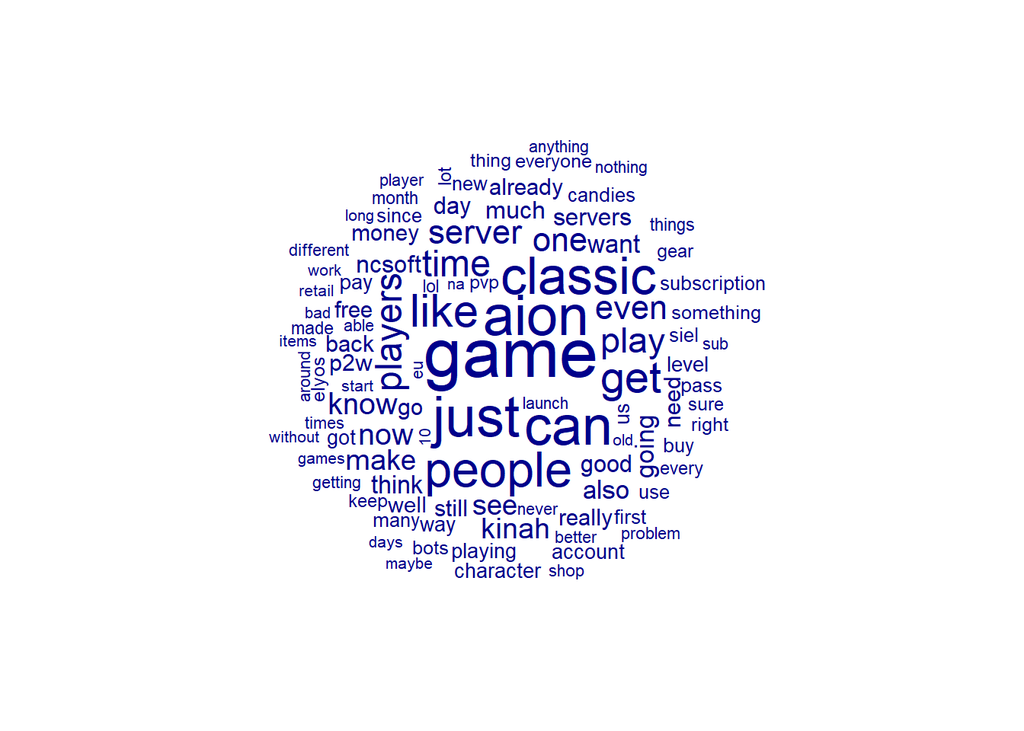

```r
#creation of a wordcloud
textplot_wordcloud(dfmat, max_words=100, min_count=10)
```

```r
#creation of a DFM for bigrams
tok_bigrams <- tokens_ngrams(toks, n = 2)
dfmat_bigrams <- dfm(tok_bigrams)
```

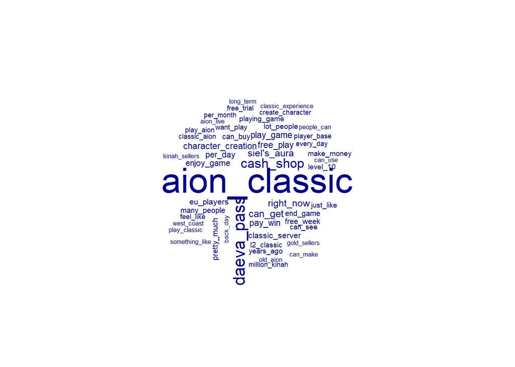

```r
#bigram wordcloud
textplot_wordcloud(dfmat_bigrams, max_words=50, min_count=10)
```

Using a feature co-occurrence matrix, we can build a semantic network and see words commonly used together.

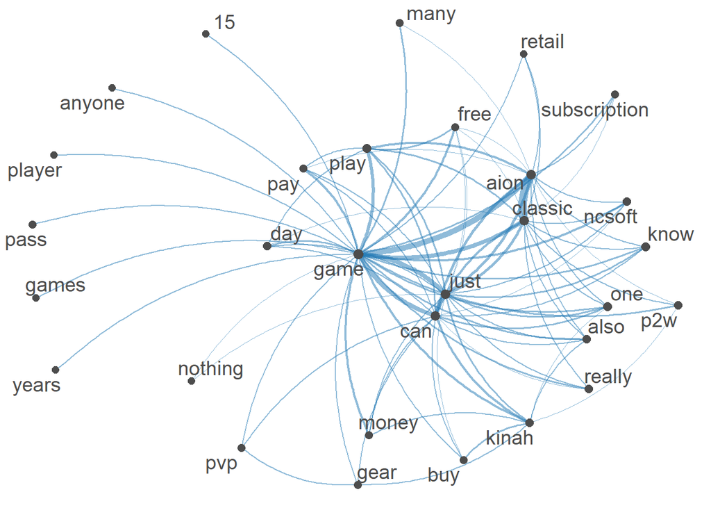

```r
#creation of a feature co-occurrence matrix
fcmat <- fcm(dfmat)
#find the top 30 features
feats <- names(topfeatures(fcmat, 30))
#visualize a semantic network of the top 30 features
size <- log(colSums(dfm_select(dfmat, feats, selection = "keep")))
fcm_select(fcmat, pattern = feats) %>% textplot_network(min_freq = 0.8, vertex_size = size / max(size) * 3)
```

The two words “just” and “players” may be interesting contextually, so we can find the words that they co-occurr mostly with.

```r
tail(fcmat[order(fcmat[, "just"]), "just"], 10)
```

```
## <sparse>[ <logic> ] : .M.sub.i.logical() maybe inefficient
```

```
## Feature co-occurrence matrix of: 10 by 1 features.
##         features
## features just
##   think   121
##   server  122
##   see     141
##   now     143
##   time    173
##   make    178
##   just    187
##   even    218
##   like    274
##   people  306
```

```r
tail(fcmat[order(fcmat[, "players"]), "players"], 10)
```

```
## <sparse>[ <logic> ] : .M.sub.i.logical() maybe inefficient
```

```
## Feature co-occurrence matrix of: 10 by 1 features.
##          features
## features  players
##   us          102
##   time        103
##   server      113
##   get         125
##   like        139
##   even        145
##   players     159
##   just        189
##   people      206
##   game        417
```

LDA can be used to discover topics within the texts. This can first be ran unseeded (i.e. unsupervised)

```r
# perform (unseeded) LDA (topic detection)
tmod_lda <- textmodel_lda(dfmat, k = 10)
```

```r
terms(tmod_lda, 10)
```

```
##       topic1   topic2     topic3    topic4         topic5    topic6     topic7    topic8      topic9   topic10
##  [1,] "play"   "server"   "aion"    "game"         "game"    "back"     "kinah"   "character" "just"   "ping"
##  [2,] "free"   "servers"  "classic" "pay"          "people"  "like"     "can"     "account"   "post"   "use"
##  [3,] "day"    "siel"     "game"    "pass"         "just"    "pvp"      "level"   "can"       "see"    "may"
##  [4,] "get"    "time"     "new"     "p2w"          "players" "good"     "get"     "create"    "know"   "using"
##  [5,] "game"   "players"  "retail"  "month"        "good"    "much"     "gear"    "one"       "us"     "used"
##  [6,] "just"   "elyos"    "years"   "shop"         "ncsoft"  "just"     "candies" "name"      "can"    "ip"
##  [7,] "people" "eu"       "back"    "subscription" "like"    "well"     "buy"     "get"       "forums" "banned"
##  [8,] "make"   "siege"    "version" "people"       "much"    "go"       "time"    "client"    "thanks" "vpn"
##  [9,] "want"   "na"       "old"     "15"           "player"  "time"     "one"     "log"       "please" "sponsor"
## [10,] "can"    "israphel" "play"    "daeva"        "keep"    "remember" "even"    "just"      "lfg"    "contest"
```

The (unseeded) LDA provides some interesting ideas for topics. Most topics do in fact correspond to an actual topic of discussion, such as the monetization, candy economy, locale of the servers, etc. **Without setting a random seed, it is possible that the specific words and topic order changes.**

To slightly improve these topics, we can use “seeded LDA”, providing predetermined topics and some seed words from a dictionary.

```r
dict_topic <- dictionary(file = "./topic_dict.yml")
print(dict_topic)
```

```
## Dictionary object with 5 key entries.
## - [monetization]:
##   - daeva, pass, candies, p2w, shop, buy, subscription
## - [localization]:
##   - eu, na, us, servers, times, time
## - [gameplay]:
##   - level, gear, pvp, ap, coins, siege, game
## - [faction]:
##   - siel, israphel, elyos, asmo, asmodian
## - [events]:
##   - sponsor, contest, entry, event, rules, official
```

```r
tmod_slda <- textmodel_seededlda(dfmat, dictionary = dict_topic)
terms(tmod_slda, 10)
```

```
##       monetization   localization gameplay faction    events
##  [1,] "p2w"          "time"       "game"   "siel"     "official"
##  [2,] "candies"      "servers"    "level"  "elyos"    "event"
##  [3,] "buy"          "us"         "gear"   "asmo"     "sponsor"
##  [4,] "pass"         "eu"         "pvp"    "israphel" "contest"
##  [5,] "subscription" "times"      "siege"  "asmodian" "entry"
##  [6,] "shop"         "na"         "ap"     "just"     "rules"
##  [7,] "daeva"        "aion"       "coins"  "people"   "account"
##  [8,] "kinah"        "classic"    "get"    "server"   "character"
##  [9,] "just"         "players"    "can"    "like"     "can"
## [10,] "can"          "server"     "just"   "know"     "use"
```

We can now assign each “paragraph” of text the most likely topic, and plot relative and absolute topic counts.

```r
head(topics(tmod_slda), 20)
```

```
##  [1] events       localization faction      faction      localization localization faction      localization localization faction
## [11] events       localization faction      localization localization monetization events       localization localization events
## Levels: monetization localization gameplay faction events
```

```r
dfmat$topic <- topics(tmod_slda)
table(dfmat$topic)
```

```
##
## monetization localization     gameplay      faction       events
##         1424         1424         1135         1529         1147
```

```r
dfm_dataframe <- data.frame(Date=dfmat$Date, topic=dfmat$topic)
```

```r
dfmcnt <- dfm_dataframe %>% count(Date, topic)
dfmcnt$Dateval <- as.Date(dfmcnt$Date,format="%B %d")
```

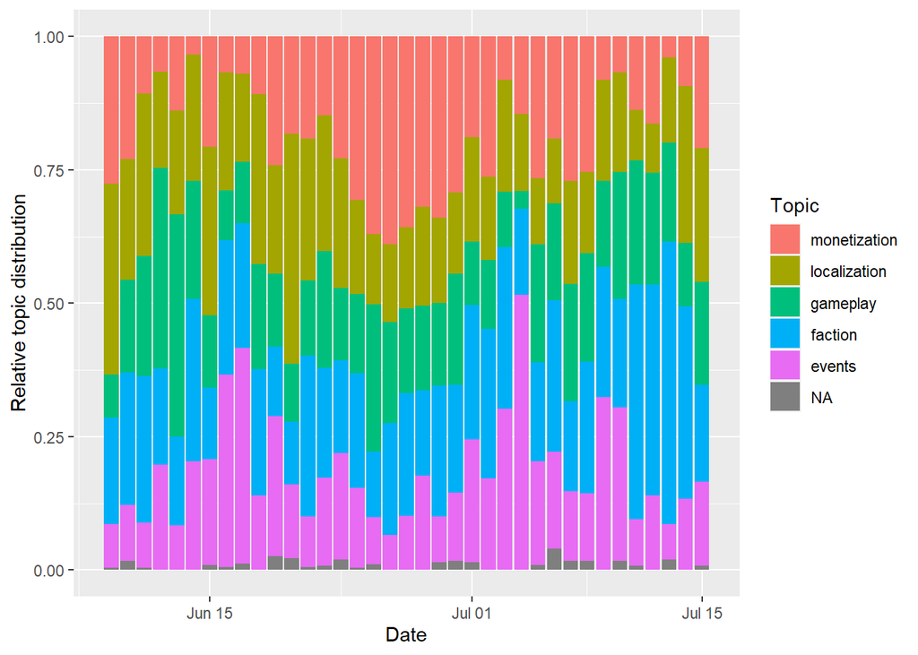

```r
plotdata <- data.frame(dfmcnt$Dateval, dfmcnt$topic, dfmcnt$n)
ggplot(plotdata, aes(fill=dfmcnt$topic, y=dfmcnt$n, x=dfmcnt$Dateval)) + geom_bar(position="fill", stat="identity") + xlab("Date") + ylab("Relative topic distribution") + labs(fill="Topic")
```

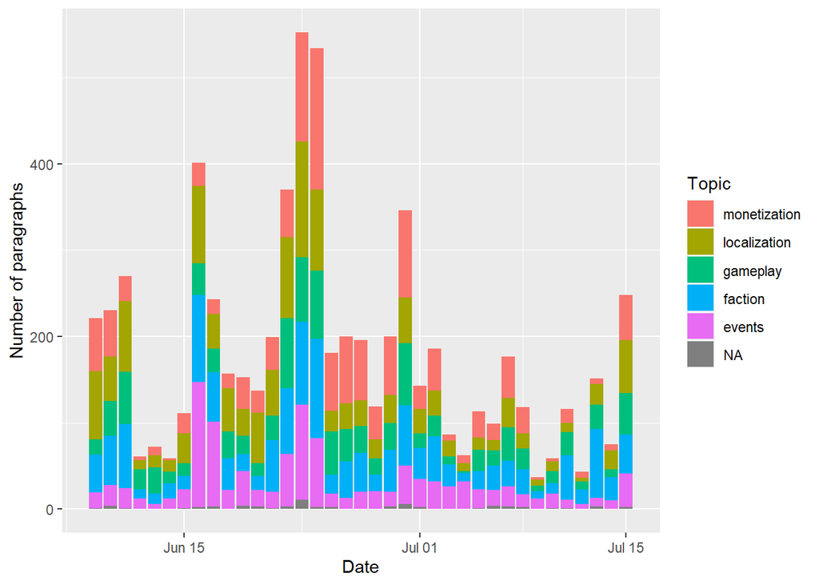

```r
ggplot(plotdata, aes(fill=dfmcnt$topic, y=dfmcnt$n, x=dfmcnt$Dateval)) + geom_bar(position="stack", stat="identity") + xlab("Date") + ylab("Number of paragraphs") + labs(fill="Topic")
```

Finally, using keyness, we can plot the relative frequency of words within a specific window (here, one week leading up to and after the release) in comparison to all other posts.

```r
dfmat$Dateval <- as.Date(dfmat$Date,format="%B %d")
tstat_key <- textstat_keyness(dfmat, target = (dfmat$Dateval >= ymd("2021-06-15")) & dfmat$Dateval <= ymd("2021-06-29"))
```

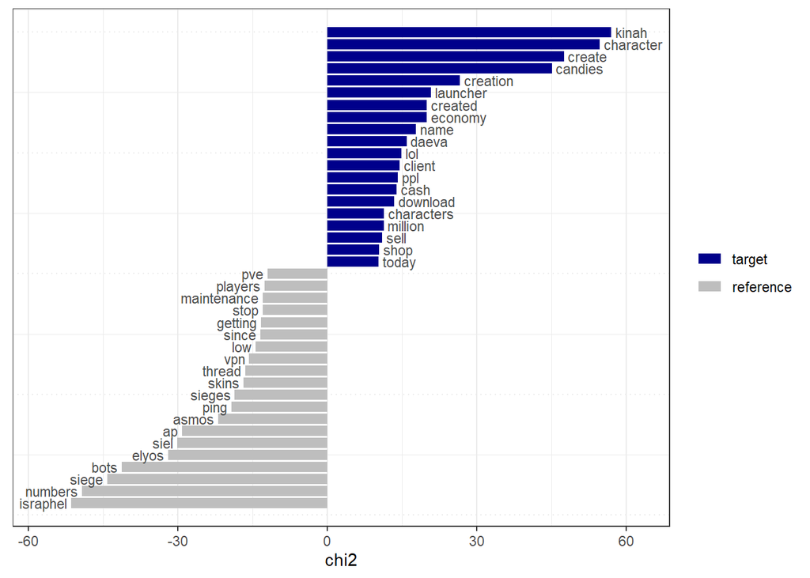

```r
textplot_keyness(tstat_key, n=20, labelsize=3, min_count=50)
```